# Why you should stop predicting customer churn and start using uplift models - ScienceDirect

## 3. Maximum profit measure

The first part of this section discusses the *maximum profit* (MP) measure for customer churn prediction, introduced in Verbeke et al. [17]. In the second part, we extend this measure to evaluating customer churn uplift models, which will subsequently allow us to meaningfully compare customer churn prediction and uplift models in Section 4.

### 3.1. Customer churn prediction models

To maximize the efficiency and returns of a retention campaign, a limited proportion of the customer base is typically targeted and given an incentive to remain loyal. Therefore, customer churn prediction models are often evaluated using, e.g., the top-decile lift measure that only accounts for the performance of the model for 10% of customers with the highest predicted probabilities of churn. Recently, Verbeke et al. [17] demonstrated that, from a profit-centric point of view, using the top-decile lift can be expected to result in suboptimal model selection. The maximum profit measure that calculates the profit resulting from targeting with a retention campaign the optimal proportion of top-ranked customers determined by the CCP model has been proposed as a business-oriented alternative. In essence, this measure evaluates a customer churn prediction model at the cutoff leading to the maximum profit rather than at an arbitrary cutoff such as 10%. Performance is expressed as the profit in monetary units that can be earned by using the model to select customers to be targeted in a retention campaign. This approach, as shown by the authors, may lead to different model selection and yield a significant increase in profitability over that of using statistical measures and that of choosing the proportion of customers to be targeted arbitrarily or based on expert opinions [17].

Fig. 3 visualizes the dynamic customer churn and retention process and allows deriving the retention campaign profit formula introduced by Neslin et al. [18]:(3)$Π=Nα[βγ(b−ccontact−cincentive)+β(1−γ)(−ccontact)+(1−β)(−ccontact−cincentive)]−A$where Π denotes the profit generated by the campaign, N is the number of customers in the customer base, *α* is the proportion of the customer base targeted in the retention campaign, *β* is the proportion of true would-be churners among customers targeted by the retention campaign, *γ* is the retention rate, i.e., the proportion of targeted would-be churners that are retained (or, in other words, the success rate of the retention campaign in persuading churners to stay), *b* is the benefit of retaining a customer (e.g., the average customer lifetime value), *c<sub>contact</sub>* is the cost of contacting a customer, *c<sub>incentive</sub>* is the cost of the incentive if a customer accepts the offer, and *A* is the fixed administrative cost of running the churn management program.

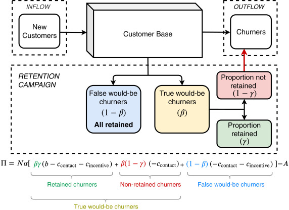

1. [Download : Download high-res image (545KB)](https://ars.els-cdn.com/content/image/1-s2.0-S0020025519312022-gr3_lrg.jpg)
2. [Download : Download full-size image](https://ars.els-cdn.com/content/image/1-s2.0-S0020025519312022-gr3.jpg)

Fig. 3. Visual representation of the formula of Neslin et al. [18]. Colors indicate matching parts of the formula and schematics.

An intuitive interpretation of the profit formula is obtained by separating Π into five parts:

**(a)**

*Nα* represents the number of customers targeted in the campaign; except for the fixed administrative costs A, only the targeted customers induce costs and benefits related to the campaign.

**(b)**

$βγ(b−ccontact−cincentive)$ represents the net profit generated by the campaign that equals the reduction in lost revenues due to churn less the costs of the campaign, $b−ccontact−cincentive,$ multiplied by the proportion *γ* of would-be churners among the proportion of correctly identified would-be churners *β* targeted by the campaign.

**(c)**

$β(1−γ)(−ccontact)$ represents the cost related to including correctly identified would-be churners who were not retained.

**(d)**

$(1−β)(−ccontact−cincentive)$ reflects the cost resulting from targeting non-churners with the campaign; these customers accept and take advantage of the incentive offered to them.

**(e)**

*A* reflects the fixed administrative cost that reduces the overall profitability of a retention campaign.

As noted in Neslin et al. [18], *β* reflects the capacity of the predictive model to identify would-be churners and can be expressed as(4)$β=λβ0$where *β*<sub>0</sub> denotes the overall churn rate, i.e., the proportion of all customers who will churn, and *λ* denotes the lift (i.e., the lift at the top-*α* percentile; cfr. top-decile lift). Rearranging the terms in Eq. (3) yields(5)$Π=Nα{[γb+cincentive(1−γ)]β0λ−cincentive−ccontact}−A$Neslin et al. [18] use the direct link between lift and profitability as a means to motivate the use of lift as a performance measure for evaluating customer churn prediction models. Verbeke et al. [17], however, show that using the lift at an arbitrary cutoff as a performance measure may lead to suboptimal model selection and, from a business perspective, a significant reduction of profitability. Therefore, the authors propose a profit-centric performance measure called the maximum profit measure, defined as [17](6)$MP=maxα(Π)$

To calculate the maximum profit measure, a pragmatic approach is typically adopted [45], and two assumptions are made: (1) the retention rate *γ* is constant and independent of the number of customers targeted by the retention campaign, and (2) the benefit *b* is constant and independent of the number of customers targeted by the retention campaign. Given the lift curve of the classification model that represents the relation between the lift and *α*, the maximum of Eq. (5) considered as a function of *α* can then be calculated straightforwardly [17] and interpreted as a measure of performance of a CCP model.

### 3.2. Customer churn uplift models

To evaluate customer churn uplift models as well as to compare CCP and CCU models, we can extend the profit formula in Eq. (3) to the uplift modeling case.

To this end, the left panel of Fig. 4 visualizes the set of *Nα* top-ranked customers in the CCP modeling case, which is regarded in the CCP profit formula of Eq. (3) as consisting of three subgroups: (1) the proportion $1−β$ (represented by the blue part) of customers who will not churn and are erroneously included in the campaign, (2) the proportion *βγ* (represented by the green part) of true would-be churners who accept the offer, and (3) the proportion $β(1−γ)$ (represented by the red part) of true would-be churners who do not accept the offer. Recall that *γ* is the campaign retention rate that is assumed to be constant and is to be estimated.

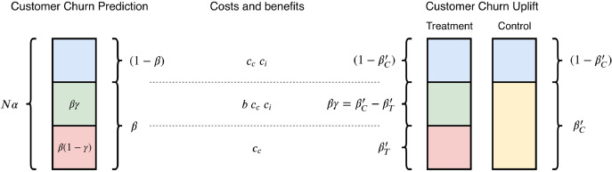

1. [Download : Download high-res image (165KB)](https://ars.els-cdn.com/content/image/1-s2.0-S0020025519312022-gr4_lrg.jpg)
2. [Download : Download full-size image](https://ars.els-cdn.com/content/image/1-s2.0-S0020025519312022-gr4.jpg)

Fig. 4. The left panel visualizes Neslin’s formula, focusing on the campaign-targeted population; the right panel provides the equivalent visualization for uplift modeling.

The right panel of Fig. 4 visualizes the set of *Nα* top-ranked customers in the CCU case. When an uplift model is developed, this set of customers will contain those from both the control group and the treatment group. For the control group, this set consists of two subgroups: (1) a proportion $βC′$ of true would-be churners, i.e., the churn rate in the control group (none of the respective customers have been retained since the control group was not targeted), and (2) a proportion $1−βC′$ of false would-be churners. Note that the proportion *β* of true would-be churners in the CCP profit formula equals the observed proportion $βC′$ of churners in the control group, i.e., the churn rate in the control group is the proportion of true would-be churners. For the treatment group, again three subgroups can be identified: (1) a proportion of false would-be churners, equal to the proportion of false would-be churners in the control group, $1−βC′$ (represented by the blue part), (2) a proportion $βT′$ of true would-be churners that are not retained, i.e., the churn rate in the treatment group (represented by the red part), and (3) a proportion $βC′−βT′$ of true would-be churners that are retained, i.e., the difference in churn rates between the control and treatment groups (represented by the green part).

Comparing the right and left panels in Fig. 4, we observe that the retained proportion of true would-be churners in the CCP profit formula equals the difference in churn rates between the control and treatment groups in the CCU case:(7)$β=βC′$(8)$β(1−γ)=βT′$from which follows:(9)$βγ=β−βT′=βC′−βT′$

The difference between the churn rates in the treatment and control groups by definition is equal to the uplift achieved at cutoff *α*:(10)$βγ=βC′−βT′=υ$Hence, in CCU modeling, the retention rate can be ascertained by comparing the churn rates in the control and treatment groups, as(11)$γ=υβ=υβC′$In CCP modeling, *γ* was estimated and assumed to be constant. This assumption clearly does not hold in uplift modeling, where the objective is to achieve increased uplift for top-ranked customers. Uplift $υ$ is explicitly indicated to be a function of cutoff *α*, as uplift is typically visualized using decile graphs or Qini curves. In the remainder of this paper, the variable retention rate is represented as $υ/βC′,$ i.e., the uplift at cutoff *α* divided by the base churn rate, which will be used in the newly introduced MPU measure for evaluating CCU models. The retention rate used in the MP measure for evaluating CCP models and assumed to be constant will always be referred to as *γ*.

Hence, Eq. (3) can be rewritten to evaluate the profitability of a retention rate under an uplift model for selecting a proportion *α* of customers as follows:(12)$Πu=Nα[(βC′−βT′)(b−ccontact−cincentive)+βT′(−ccontact)+(1−βC′)(−ccontact−cincentive)]−A$

Note that $βC′,$ $βT′$ and, as a result, $υ,$ are a function of *α*. If *α* is equal to one, then $βC′$ and $βT′$ are equal to churn rates observed in the full control and treatment groups, respectively. As in Eq. (5), we may define a measure similar to lift that characterizes the performance of an uplift model by comparing the performance of the model in terms of the achieved uplift at proportion *α* to the overall uplift achieved when targeting the entire population.

We introduce and formally define liftup *λ<sub>u</sub>* as follows:(13)$βC′−βT′=υ=υ0*λu$where $υ0$ is the baseline uplift achieved when targeting the full customer base. Note that similarly to a lift curve, a liftup curve can be plotted to provide a visual evaluation of an uplift model. Additionally, the top-decile liftup may be reported, as well as the liftup at any other percentile cutoff, consistently with the practice of, e.g., reporting the top-decile lift. In the experimental section below, liftup curves are provided for illustration. Rewriting Eq. (12) yields(14)$Πu=Nα[υ0*λu*b−ccontact−(1−βT′)*cincentive]−A$

As to CCP modeling, the final objective of an uplift model is to maximize the profit earned as a result of a retention campaign, as expressed by Eq. (14), yielding the maximum profit uplift (MPU) measure:(15)$MPU=maxα(Πu)$

The MPU measure expresses the performance of a CCU model in terms of profit earned per customer in the customer base when targeting the optimal proportion of customers ranked according to the estimated uplift determined by the CCU model. While MPU gives us the maximum achievable profit, this is easily extended to the argmax of *alpha* to give us the most optimal proportion of the population to target. This leads to new managerial implications as to the setup of a marketing campaign.

## 4. Experiments

The experiments reported in this section allow comparing and contrasting customer churn prediction and customer churn uplift modeling. In the first part of this section, Section 4.1, information about the experimental setup, i.e., the dataset and experimental methodology, is provided. The results of experiments are presented in Section 4.2, and are discussed and analyzed in detail in Section 4.3.

### 4.1. Experimental design

#### 4.1.1. Dataset

The dataset used in the experiments was obtained from a financial institution. It consists of records containing customer information, including a churn indicator and a variable determining whether a customer was targeted with a retention campaign. In this context, a customer who churns corresponds to an active total defection due to contract termination. Table 2 provides detailed information about the dataset. The retention campaign was targeted at a treatment group for which, in the subsequent three-month period, a churn rate of 13.25 % was observed. For the control group, which was not targeted by the retention campaign, a significantly higher churn rate of 25.52 % was observed. The baseline uplift $υ0,$ introduced in the previous section, that was achieved by the retention campaign thus equals 12.27 %. The dataset includes 162 variables, including sociodemographic data as well as usage and activity indicators.

Table 2. Information on the dataset obtained from a European financial institution.

| Data Type of organization | Data Financial institution |
| --- | --- |
| Total number of observations | 200,903 |
| Total number of variables | 162 |
| Number of control group observations | 118,809 |
| Control group churn rate | 25.52% |
| Number of treatment group observations | 82,094 |
| Treatment group churn rate | 13.25% |
| Overall Uplift | 12.27% |

#### 4.1.2. Methodology

Random stratified sampling was applied to the treatment and control groups to obtain training and test sets including 2/3 and 1/3 of records, respectively. To establish the CCP model, only the training set that was sampled from the control group is used; in contrast, the training set that was sampled from both the treatment and control group is used in learning the CCU model. To compare the performance of the resulting CCP and CCU models, two scenarios are considered. In the first, the *classic* MP profit measure is used (cfr. Eq. (3)) for evaluating both CCP and CCU models, which requires using the test set of the control group. In the second scenario, the novel MPU measure is adopted (cfr. Eq. (12)) for testing the CCP and CCU models, which requires both test sets that were sampled from the treatment and control groups.

Two modeling techniques—logistic regression and random forests—are used to develop CCP and CCU models. Both techniques can be used straightforwardly to develop predictive models and have been adapted to developing uplift models [11], [32]. The decision to apply these two techniques in the experiments is motivated as follows. Logistic regression is the standard predictive modeling approach used in industrial settings across various applications and is a typical benchmark approach used in experimental studies and scientific research. Additionally, logistic regression facilitates the interpretation of the resulting model and typically performs well [14], [46]. Random forests, on the other hand, represent the state-of-the-art in the field of business analytics, are widely applied in the industry as well as in scientific research, and typically achieve strong performance [14], [46]. Note that a full-scale benchmarking analysis including a broad range of predictive and uplift modeling techniques for various datasets is beyond the scope of this study.

To perform the experiments, open source R software is used [47]. CCP modeling relies on implementations in R package *Caret* [48]. For CCU modeling, adapted implementations were used to take into account and contrast customer behavior of the treatment and control groups. Nonetheless, the underlying learning approach of the CCU methods is similar to that adopted by their predictive modeling counterparts. For logistic regression, Lo’s approach was used [11] in our experiments to facilitate comparison with the standard logistic regression, whereas the uplift random forests method proposed in Guelman et al. [32] was used via R package *uplift* [49] and compared with the standard random forests method introduced by Breiman [50].

### 4.2. Results

#### 4.2.1. Scenario 1 - Evaluation with maximum profit

This section reports results of experiments for the first scenario in which the MP measure is used to evaluate the performance of logistic regression and random forests CCP and CCU models, as detailed above. Fig. 5 shows the profit curves for the experiments for scenario 1. As no information was provided by the financial institution regarding the actual values of the cost and benefit parameters of the MP measure, three different sets of parameters are used to calculate MP that are based on values reported in the literature [17], [18] and represent cases of low, medium and high returns resulting from retaining a customer. A full sensitivity analysis of the impact of the adopted cost and benefit parameters is beyond the scope of this study and is recognized as a topic for further research. However, the results of experiments performed using the three sets of parameters are fully consistent, and thus conclusions drawn from the experiments appear to hold irrespective of the assumed parameter values.

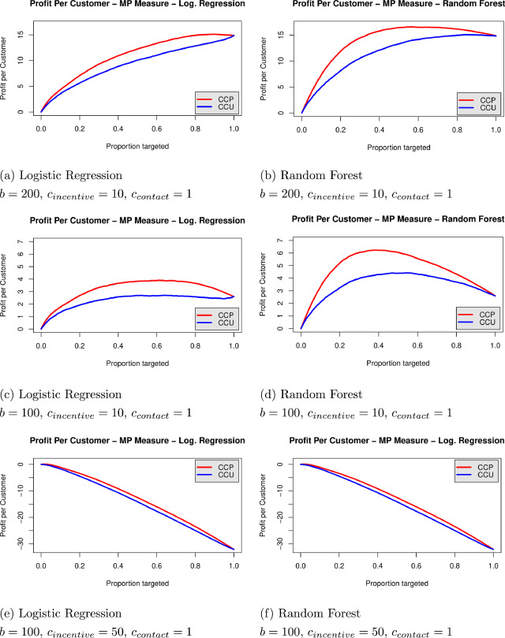

1. [Download : Download high-res image (884KB)](https://ars.els-cdn.com/content/image/1-s2.0-S0020025519312022-gr5_lrg.jpg)
2. [Download : Download full-size image](https://ars.els-cdn.com/content/image/1-s2.0-S0020025519312022-gr5.jpg)

Fig. 5. Profit curves for logistic regression (left) and random forests (right) CCP (red curves) and CCU (blue curves) models for the first scenario using the MP measure for three sets of cost and benefit parameters. (For interpretation of the references to colour in this figure legend, the reader is referred to the web version of this article.)

The profit curves presented in Fig. 5 show the profits earned per customer of the customer base for a proportion *α* (shown on the x-axis) of customers targeted by the retention campaign. These values may be ranked based on the estimated probability of churn according to CCP models (red profit curves) or based on the estimated uplift score of CCU models (blue profit curves). Note that the profit earned per customer of the customer base, rather than the total profit, is plotted because the former is independent of the size of the customer base and proportional to the total profit. Therefore, the profit curves illustrate the optimal proportion of customers to be targeted by the retention campaign, giving rise to the maximum profit.

#### 4.2.2. Scenario 2 - Evaluation with maximum profit uplift

Fig. 6 shows the profit curves for the experiments for the second scenario detailed in the previous section, with the results of the CCP and CCU models evaluated using the novel *maximum profit uplift* performance measure. The MPU measure includes both treatment and control group observations in the test set of the evaluation.

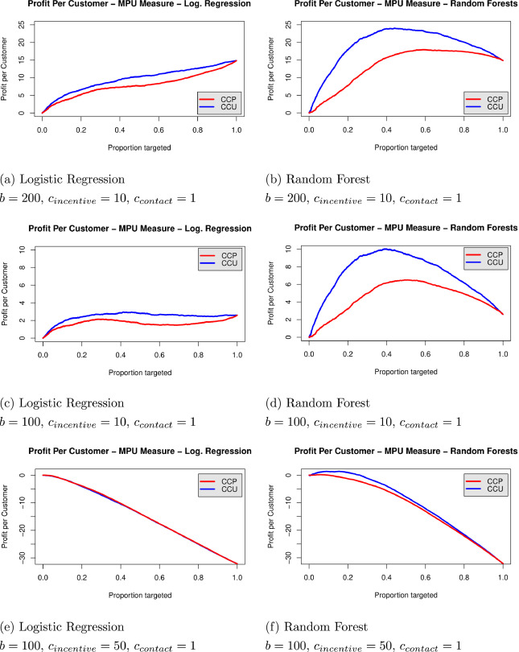

1. [Download : Download high-res image (868KB)](https://ars.els-cdn.com/content/image/1-s2.0-S0020025519312022-gr6_lrg.jpg)
2. [Download : Download full-size image](https://ars.els-cdn.com/content/image/1-s2.0-S0020025519312022-gr6.jpg)

Fig. 6. Profit curves for logistic regression (left) and random forests (right) CCP (red curves) and CCU (blue curves) models for the second scenario using the MPU measure for three sets of cost and benefit parameters. (For interpretation of the references to colour in this figure legend, the reader is referred to the web version of this article.)

### 4.3. Discussion

We consider our results from three different perspectives. First, in Section 4.3.1 we examine the profit curves according to MP and MPU formulas. Second, in Section 4.3.2 we assess the churn rate and the corresponding lift and liftup curves. Finally, in Section 4.3.3 we focus on the rank correlation between different setups.

#### 4.3.1. Profit curves

The evaluation based on the MP measure for scenario 1 clearly shows that CCP modeling yields higher profits than does CCU modeling for logistic regression and random forests. The profit curves shown in Fig. 5 for CCP models dominate the profit curves of CCU models. We conclude that CCP models are superior in predicting which customers will churn. This is reasonable, as CCP models are trained with the objective of predicting churn, whereas uplift models are developed to predict uplift. Many of the churners identified by the CCP model can be hypothesized to be lost causes. Many churners can also be expected to have made up their minds and to not be persuaded by a retention campaign. A successful uplift model should rank these customers *at the bottom of the ranking*; i.e., it should estimate their uplift as being close to zero since the retention campaign does not yield any effect. Then, if MP is used as the evaluation measure, it is straightforward to observe that CCP performs better than CCU since CCP models better predict churn, and MP assumes a constant retention rate for targeted churners. In particular, MP does not acknowledge that the retention rate will be as low, if lost causes are targeted, as the true retention rate can be observed if both control and treatment groups are available. As the MP measure is heavily influenced by the predictive power of a model, MP will indicate that the CCP model is superior to CCU models.

This is confirmed by the analysis of results of experiments for scenario 2. Using the MPU measure to evaluate the performance of CCP and CCU models, we observe that CCU models outperform CCP models. This can be attributed to the fact that uplift models effectively succeed in predicting uplift, which is accounted for in the MPU measure, as discussed in Section 3.2, by having the variable retention rate be a function of the targeted proportion of customers *α*. When ranking both the treatment and control groups in the test set according to the predicted probabilities of churn determined by CCP models and according to the predicted uplift determined by CCU models, we can compare the reduction in churn rate as a function of the selected proportion *α* plotted along the x-axis for both models. As CCP models assign high rank to customers who are likely to churn but may not necessarily be retained (which is exactly what the CCU model aims to do), CCP models are observed to be less effective in reducing churn and hence to be less profitable than CCU models. The objective of CCU models is to ascribe high scores to customers who are likely to both churn and be retained, and as such, they achieve higher degrees of uplift and profitability.

Note that it is only possible to calculate the MPU measure if both control and treatment groups are present, which is not the case in traditional customer churn prediction setups. The MP measure is still useful in such settings, but the results of experiments indicate that uplift modeling is a superior paradigm with respect to developing a data-driven customer retention program.

In addition, although it is of less importance here, the obtained profit curves clearly show that random forests outperform logistic regression in this case. Random forest models can generate higher profits per customer and higher profits from a smaller proportion of customers targeted by a retention campaign. This result is unsurprising and is fully consistent with the results of benchmarking experiments performed across various business domains and reported in the literature [2], [17].